# 7.25数据可视化培训

北师统计研会 焦晨洁

# 内容介绍

- 一，配色
- 二，Python绘图
- 三，R绘图

# 配色

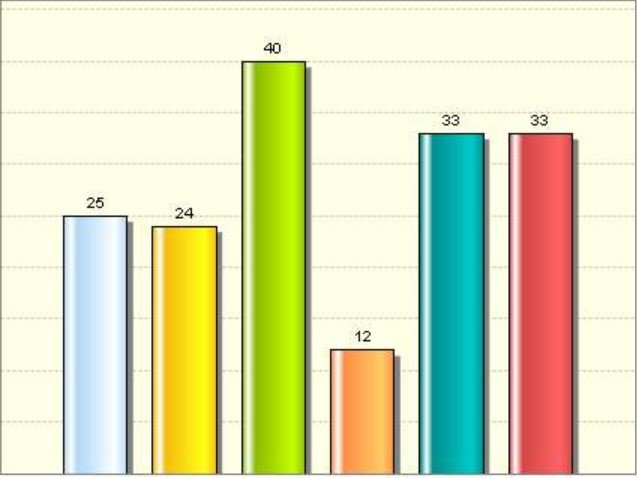

```python
from IPython.display import Image
Image(filename = 'C:/Users/JCJ0716/Desktop/725数据可视化/python/配色1.jpg', width=300, height=100)
```

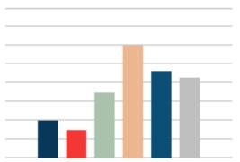

```python
Image(filename = 'C:/Users/JCJ0716/Desktop/725数据可视化/python/配色2.jpg', width=300, height=100)
```

- 一种颜色分深浅，透明度，经常用的蓝色（#02a4de）,金色（gold）和灰色（grey/grey40）
- 颜色表： https://blog.csdn.net/benbenhai1999/article/details/52648386
- 专业的配色网站 https://coolors.co/5596cb #演示
- https://www.sohu.com/a/148389742_417040

# Python

## 需要使用的包

```python
#导入所有可能用到的包
import random
import math
import pandas as pd
import numpy as np
import matplotlib.pyplot as plt
import matplotlib.ticker as mtick
from IPython.display import Image
plt.rcParams['font.sans-serif'] = [u'SimHei']#这两行显示中文
plt.rcParams['axes.unicode_minus'] = False
%matplotlib inline
```

## 柱状图

主要函数：plt.bar

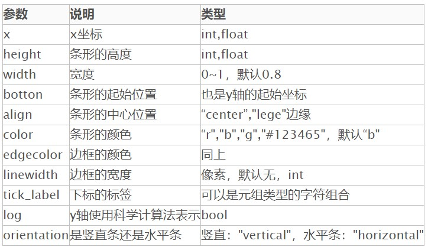

```python
Image(filename = 'C:/Users/JCJ0716/Desktop/725数据可视化/python/bar.jpg', width=500, height=100)
```

图中botton==>bottom

[1]https://www.cnblogs.com/zyg123/p/10504637.html

### 单组柱状图

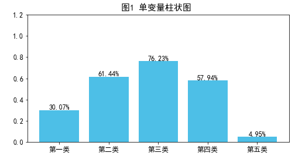

```python
#控制图片大小以及清晰度
fig = plt.figure(figsize=(8,4), dpi=72)#150 演示

# 构建数据
x_data = ['第一类','第二类', '第三类','第四类','第五类']
y_data =  np.random.random(5)

# 绘图
plt.bar(x=x_data, height=y_data, color='#02a4de', alpha=0.7)#颜色，透明度  演示alpha
plt.tick_params(labelsize=12)#标签字体大小 演示

# 在柱状图上显示具体数值, ha参数控制水平对齐方式, va控制垂直对齐方式，百分数的表示方法
for x, y in enumerate(y_data):
    plt.text(x,y + 0.005, str('{:.2f}'.format(y *100)) +'%',ha='center',size = 12) #位置，高度，内容，居中

#演示y,ha

#设置y轴范围
plt.ylim(0,1.2)#演示

# 设置标题
plt.title('图1 单变量柱状图 ',size = 15)

# 设置坐标轴标题
plt.xlabel(" ",size = 12)
plt.ylabel(" ",size = 12)

#画图
plt.show()
```

### 双组柱状图

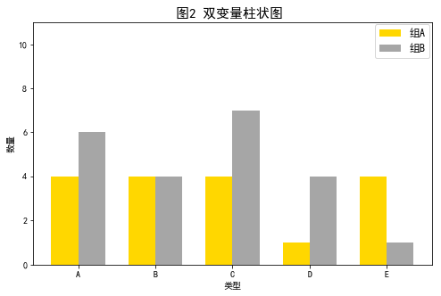

```python
#控制图片大小以及清晰度
fig = plt.figure(figsize=(8,5), dpi=72)

# 构建数据
x = np.arange(5)#一共5组
tick_label = ["A", "B", "C", "D", "E"]#每一组的名称
y = np.random.randint(1,10,5)
y1 = np.random.randint(1,10,5)#每一组数据

#设置柱体宽度
bar_width = 0.35

#绘图
plt.bar(x, y, bar_width, align="center", color="gold", label="组A", alpha=1)
plt.bar(x+bar_width, y1, bar_width, color="grey", align="center", label="组B", alpha=0.7)

#设置y轴范围
plt.ylim(0,11)

# 设置标题
plt.title('图2 双变量柱状图 ',size = 15)

#坐标轴名称
plt.xlabel("类型")
plt.ylabel("数量")

#把X轴的名称换成ABCDE
plt.xticks(x+bar_width/2, tick_label)

#设置图例位置
plt.legend(loc="upper right",borderaxespad=0.2,fontsize = 12)
#upper-center-lower,left-center-right


plt.show()
```

### 堆积柱状图

如果说双柱状图是把X轴的位置换了，那么堆积图就是把Y轴的位置换了，用到的就是Bottom这个参数

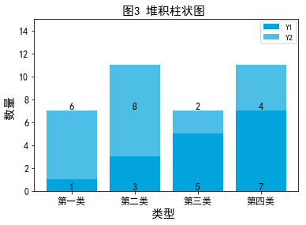

```python
#控制图片大小以及清晰度
fig = plt.figure(figsize=(6,4), dpi=72)

#数据
x = ['第一类','第二类', '第三类','第四类']
y_data1 = [1,3,5,7]
y_data2 = [6,8,2,4]

#z_data = list(np.sum([y_data1,y_data2], axis = 0))

plt.bar(x, y_data1, label='Y1', color='#02a4de',alpha = 1 )  #透明度设置不同的颜色
plt.bar(x, y_data2, label='Y2',bottom=y_data1, color='#02a4de',alpha = 0.7 )
plt.tick_params(labelsize=12)

#数据标签
for x, a in enumerate(y_data1):
    plt.text(x,0.1 , a,ha='center',size = 12) #位置，高度，内容，居中
for x, b in enumerate(y_data2):
    plt.text(x,7,b,ha='center',va = 'bottom',size = 12)

#y轴范围
plt.ylim(0,15)

# 设置标题
plt.title('图3 堆积柱状图 ',size = 15)

# 为两条坐标轴设置名称
plt.xlabel("类型 ",size = 15)
plt.ylabel("数量 ",size = 15)

# 显示图例
legend = plt.legend(loc='best',borderaxespad=0.2,fontsize = 10)


plt.show()
```

## 折线图

主要函数：plt.plot

- 线形参数 linestyle

```python
table1 = {'形状': ["'-'","'--'","'-.'","':'","' '"],
             '线型': ['实线','虚线','虚点线','点线','空类型,不显示线']}
table1 = pd.DataFrame(table1)
table1
```

|  | 形状 | 线型 |
| --- | --- | --- |
| 0 | '-' | 实线 |
| 1 | '--' | 虚线 |
| 2 | '-.' | 虚点线 |
| 3 | ':' | 点线 |
| 4 | ' ' | 空类型,不显示线 |

- 标记参数 marker

```python
table2 = {'形状': ["','","'o'","'^'","'*'","'p'","'s'"],
             '线型': ['点','圆点',"三角点（'<':左三角，'>'：右三角）",'星星点','五边形','四边形']}
table2 = pd.DataFrame(table2)
table2
```

|  | 形状 | 线型 |
| --- | --- | --- |
| 0 | ',' | 点 |
| 1 | 'o' | 圆点 |
| 2 | '^' | 三角点（'<':左三角，'>'：右三角） |
| 3 | '*' | 星星点 |
| 4 | 'p' | 五边形 |
| 5 | 's' | 四边形 |

### 单条折线图

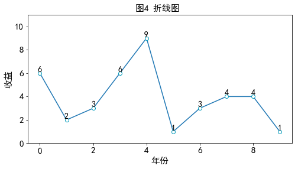

```python
#控制图片大小以及清晰度
fig = plt.figure(figsize=(8,4), dpi=72)

#数据
x = np.arange(10)
y =  np.random.randint(1,10,10)

#绘图
plt.plot(x, y,linestyle = '-', marker='o', mec='#029bbb', mfc='w')#mfc：点中空心的颜色
plt.tick_params(labelsize=15)


#y轴范围
plt.ylim(0,11)


#标记数据标签
for x, a in enumerate(y):
    plt.text(x,a+0.1, a,ha='center',size = 14) #位置，高度，内容，居中

# 设置标题
plt.title('图4 折线图 ',size = 15)


# 为两条坐标轴设置名称
plt.xlabel('年份',size = 15)
plt.ylabel("收益",size = 15)
```

### 多条折线图

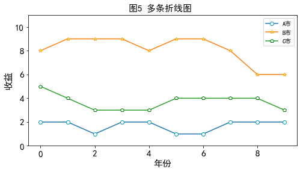

```python
#控制图片大小以及清晰度
fig = plt.figure(figsize=(8,4), dpi=72)

#数据
x = np.arange(10)
y_1 = np.random.randint(1,3,10)
y_2 = np.random.randint(3,6,10)
y_3 = np.random.randint(6,10,10)

#绘图
plt.plot(x, y_1, marker='o', mec='#029bbb', mfc='w',label='A市')
plt.plot(x, y_3, marker='*',  mec='orange', mfc='w',label='B市')
plt.plot(x, y_2, marker='p',  mec='green', mfc='w',label='C市')


#刻度字体大小
plt.tick_params(labelsize=15)

#y轴范围
plt.ylim(0,11)

# 设置标题
plt.title('图5 多条折线图 ',size = 15)

#图例设置
plt.legend()

# 为两条坐标轴设置名称
plt.xlabel('年份',size = 15)
plt.ylabel("收益",size = 15)
```

## 组合：柱状图和折线图组合—双轴的情况

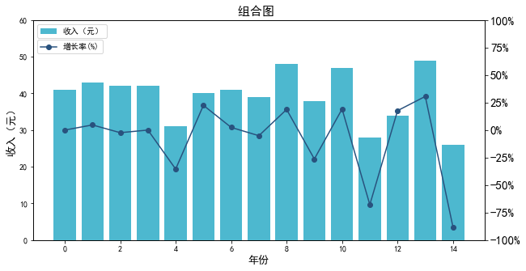

```python
#控制图片大小以及清晰度
fig = plt.figure(figsize=(10,5), dpi=72)


#--------------设置数据-----------------

#柱状图
a=np.random.randint(25,50,15)

#折线图
b=np.random.random(15)
for i in range(14):
    x = float(a[i+1])
    y = float(a[i])
    b[i+1] = (x-y)/x
b[0] = 0
b = b*100

#标签
x=[i for i in range(15)]
#---------------以上为数据---------------


#设置柱状图的坐标轴
ax1 = fig.add_subplot(111)  #a three-digit number
#111”表示“1×1网格，第一子图”，“234”表示“2×3网格，第四子图

plt.bar(x,a,alpha=0.7,color='#029bbb',label=u'收入（元）')
ax1.set_ylabel('收入（元）',size =13)
ax1.set_xlabel('年份',size =13)
ax1.set_ylim([0, 60])  #设置y轴取值范围
plt.legend(loc="upper left")


#设置折线图的坐标轴——百分比形式的坐标轴
ax2 = ax1.twinx() #对ax1调用twinx()方法，生成如同镜面效果后的ax2
ax2.plot(x, b,'or-',color='#29527e',label=u'增长率(%)')
fmt='%.f%%'
yticks = mtick.FormatStrFormatter(fmt)
ax2.yaxis.set_major_formatter(yticks)
ax2.set_ylim([-100, 100])
plt.legend(loc="upper left", bbox_to_anchor=(0,0.93))


#刻度字体大小
plt.tick_params(labelsize=15)


# 设置标题
plt.title('组合图 ',size = 15)

plt.show()
```

## 饼图

主要函数：plt.pie

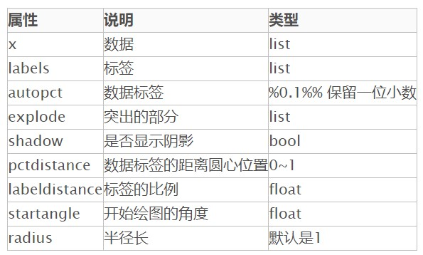

```python
Image(filename = 'C:/Users/JCJ0716/Desktop/725数据可视化/python/pie.jpg', width=400, height=100)
```

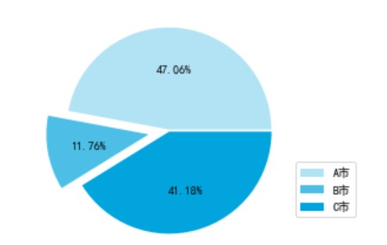

```python
Image(filename = 'C:/Users/JCJ0716/Desktop/725数据可视化/python/突出例子.jpg', width=300, height=100)
```

[2]https://www.cnblogs.com/zyg123/p/10504640.html

### 饼图

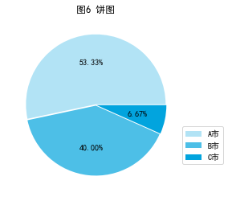

```python
#控制图片大小以及清晰度
fig = plt.figure(figsize=(4,4), dpi=72)#将画布设定为正方形，则绘制的饼图是正圆

#设置数据
label=['A市','B市','C市']#定义饼图的标签，标签是列表
explode=[0.01,0.01,0.01]#设定各项距离圆心n个半径  #演示尝试突出显示
values = np.random.randint(1,10,3)
colors=['#B2E3F5','#4DBFE7','#02A4DE']

#绘制饼图
plt.pie(values,explode=explode,colors=colors,autopct='%1.2f%%')# shadow=True增加阴影

#绘制标题labels=label,
plt.title('图6 饼图')

#绘制图例
plt.legend(label,loc="upper right", bbox_to_anchor=(1.25,0.4))

plt.show()
```

### 环形图

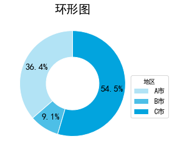

```python
#控制图片大小以及清晰度
fig = plt.figure(figsize=(4,4), dpi=72)#将画布设定为正方形，则绘制的饼图是正圆

#设置数据
label = ['A市','B市','C市']
values = np.random.randint(1,10,3)
colors=['#B2E3F5','#4DBFE7','#02A4DE']

#绘图
wedges, texts, autotexts = plt.pie(values,
    autopct = '%3.1f%%',
    radius = 1,                                   #圆的半径
    pctdistance = 0.75,                           #数据标签的半径
    colors = colors,                              #每一部分的颜色
    startangle = 90,                              #起始角度
    textprops = {'color': 'black'},               #数据标签的颜色
    wedgeprops = {'width': 0.5, 'edgecolor': 'w'} #环的宽度，以及边框颜色
)

# 图例
plt.legend(wedges,
           label,
           fontsize = 12,
           title = '地区',
           loc = 'center right',
           bbox_to_anchor = (1.25,0.4))

# 设置文本样式
plt.setp(autotexts, size=15, weight='bold')

# 标题
plt.title('环形图', fontsize=20)

plt.show()
```

## 极坐标绘图

- 在平面内取一个定点O，叫极点，引一条射线Ox，叫做极轴，再选定一个长度单位和角度的正方向（通常取逆时针方向）。对于平面内任何一点M，用ρ表示线段OM的长度（有时也用r表示），θ表示从Ox到OM的角度，ρ叫做点M的极径，θ叫做点M的极角，有序数对 (ρ,θ)就叫点M的极坐标，这样建立的坐标系叫做极坐标系。[百度百科]

[figure not shown]

```python
Image(filename = 'C:/Users/JCJ0716/Desktop/725数据可视化/python/极坐标.png', width=500, height=100)
```

- 主要函数 plt.polar

### 简单尝试

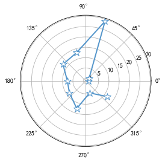

```python
n = 10
#theta指每个标记所在射线与极径的夹角，下面表示均分角度

theta = np.linspace(0.0, 2*np.pi, n, endpoint=False)

#r表示点距离圆心的距离，np.random.rand(barSlices)表示返回返回服从“0-1”均匀分布的随机样本值

r = 30*np.random.rand(n)

#polar表示绘制极坐标图，颜色，线宽，标志点样式

plt.polar(theta, r, color="#5596CB", linewidth=2, marker="*", mfc="w", ms=12)#ms标记的大小
```

- theta极角确定有几个点，点的角度，r极径确定长度

### 心形线

- 参数方程的公式 $$x=a(2cos(t)-cos(2t))$$ $$y=a(2sin(t)-sin(2t))$$
- 极坐标公式 $$r = a(1-\sin(\theta))$$
- 用上面的方法

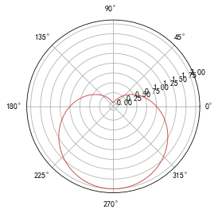

```python
#theta指每个标记所在射线与极径的夹角，下面表示均分角度

theta = np.linspace(0, 2 * np.pi, 1024)

#r表示点距离圆心的距离，np.random.rand(barSlices)表示返回返回服从“0-1”均匀分布的随机样本值
a = 1
r = a*(1. - np.sin(theta))

#polar表示绘制极坐标图，颜色，线宽，标志点样式

plt.polar(theta, r, color="#CC5656", linewidth=1, marker=" ", mfc="w")
```

- 另一种方法

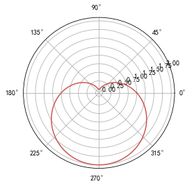

```python
t = np.linspace(0, 2 * np.pi, 1024)
plt.axes(polar = True)
plt.plot(t, 1. - np.sin(t),color="#CC5656")
```

[3]https://blog.csdn.net/wireless_com/article/details/69817498

## 推荐阅读（Pyecharts）

- 数据可视化:https://www.jianshu.com/p/b718c307a61c
- 南丁格尔玫瑰图:https://blog.csdn.net/kaikai_sk/article/details/104954309
- matplotlib包的原理：https://www.cnblogs.com/zyg123/p/10512513.html

# R-ggplot2使用总结

2020/7/21

# 1、ggplot2

ggplot2是R画图中非常重要的一个包相比于一般的plot包，它的功能更强，形式更加多样化，可以更好的实现R语言可视化的问题。这一篇文章主要说明一些基础的ggplot2包的使用的例子，对于更多参数的详细含义还是建议查看help文档，语言较为通俗，如有错误欢迎指出！

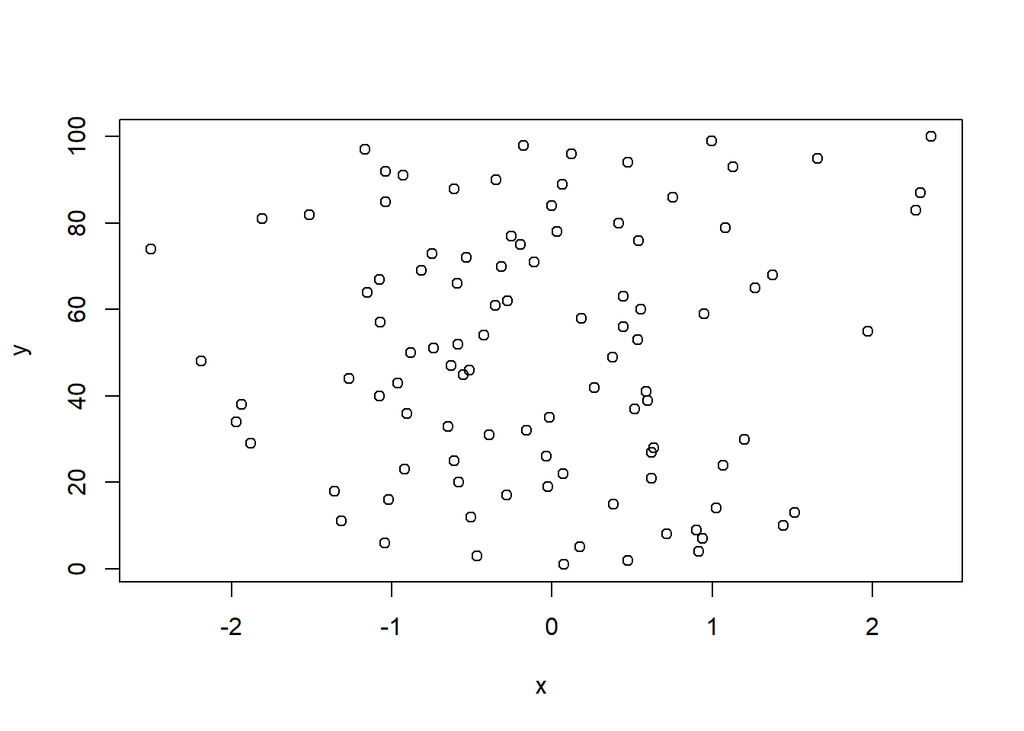

```r
#plot的简单使用
x = rnorm(100)
y = seq(1,100,1)
plot(x,y)
```

首先ggplot2画图主要是运用的图层叠加的方法，通过一个一个的‘+’号将图层逐渐叠加形成最后我们需要的图像。ggplot2画图首先要有一个主函数：

- ggplot()

然后叠加其他图层，实现画图：

- geom_bar(),geom_point(),geom_line()等，适用于绘制柱状图，折线图，点图等
- labs()对图像的轴进行设置
- theme()对图像的样式进行设置

当然针对不同的图形还会有一些更为特别的函数，将在后续的内容中涉及。本文主要将利用三种常用的图形进行说明，分别是柱状图，折线图，以及箱线图。ggplot2画图所用的程序其实大同小异所以可以自行根据这三个图形进行拓展。

为更好的说明绘图方法，这里采用一个自己制作的无实际意义的数据集。由于本文的重点是画图，所以所用数据经过处理可以直接使用进行画图。

## 1.1准备工作

```r
# 清除历史记录
rm(list=ls())
# 导入使用的包
library(openxlsx)#导入数据
library(ggplot2)#绘图
library(tidyverse)
library(broom)
```

## 1.2通用的参数解释

- df %>%:表示作图所需要的数据均来自df数据集，这一语句需要tidyverse包的支持。(安装和导入包的方法)
- ggplot(…)：这一语句说明了ggplot2的数据层和映射层,单有此层是没有图像展示的。
- labs(…)：对图像的坐标轴的命名。
- theme(…)：图表主题的设定。本文的设定中对坐标轴字体大小以及坐标轴标题的字体大小，以及背景设置为透明，轴线设置为黑色等等，ggplot也有默认的主题设定，更多的可以自行搜索。

# 2、柱状图

## 2.1柱状图参数解释

首先介绍最常使用的柱状图，这一图形绘制主要使用了geom_bar(…)函数，通过使用不同的参数设置可以得到不同的柱状图，条形图，堆积柱状图等等，常用的中参数含义如下表所示：

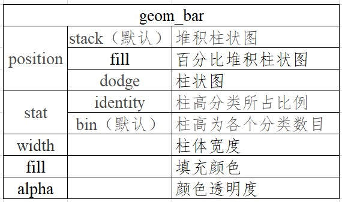

## 2.2单组柱状图

- 为展示具体的使用方法，这一部分尝试绘制2019年index排名前十的地区柱状图，导入数据并展示数据集的前5行，然后绘制柱状图，并且按照index的降序排列。

```r
df1<-read.xlsx("mydata.xlsx",1)                             #导入index数据
df1[1:5,]                                                #数据展示
```

```
##   area index2019
## 1    A 135.23486
## 2    B 125.13719
## 3    C  89.26078
## 4    D  78.31411
## 5    E  68.14956
```

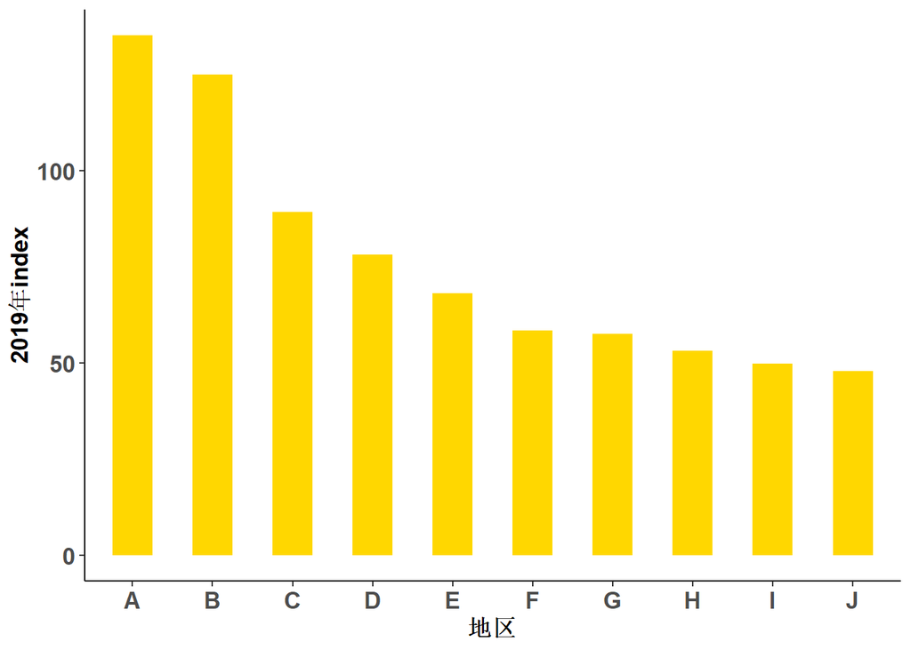

```r
df1 %>%
  ggplot()+
  geom_bar(aes(x = factor(reorder(area, -index2019)),      #设置x为因子型变量，按index降序排列
               y=index2019,fill=area),
           position="dodge",                            #柱状图
           stat="identity",
           width=0.5,fill="gold",alpha = 1)+          #柱体宽度0.5，填充金色，透明度0.9
  labs(x = "地区", y = "2019年index") +                    #设置x,y轴
  theme(axis.text = element_text(face = "bold",size=13), #设置坐标轴文字大小和样式
      axis.title = element_text(face = "bold",size=13),  #设置坐标轴标题文字大小和样式
      panel.background = element_rect(fill = "transparent"), #设置背景
      panel.border=element_rect(fill='transparent',
                                color='transparent'),
      axis.line = element_line(color = "black"))         #设置轴线
```

```r
      #+coord_flip()                                       #加入可以转换为条形图
#+一定要在上一行的结束
```

对于多组柱状图时，则首先需要注意数据集的形式，不同于一般的Excel绘图的数据格式，需要将所有类型的数据都在一列，增加分类列以区别分组。然后会用到一些函数对不同分组的分组进行设置。

## 2.3双组柱状图

- 双组的柱状图也常常用来对比两类事物的不同之处，为展示这一方法尝试绘制2019年index排名前十的地区的2018和2019index的柱状图。和单种柱状图不同之处在于对于不同分组的数据要设置颜色等等,所以这里引入的新的函数scale_fill_manual通过设置breaks,values,以及labels即可完成对于不同分组的数据的图像的设定。

```r
df2<-read.xlsx("mydata.xlsx",2)                       #导入index数据
df2[1:5,]                                             #数据展示
```

```
##   area     index year
## 1    A 135.23486 2019
## 2    B 125.13719 2019
## 3    C  89.26078 2019
## 4    D  78.31411 2019
## 5    E  68.14956 2019
```

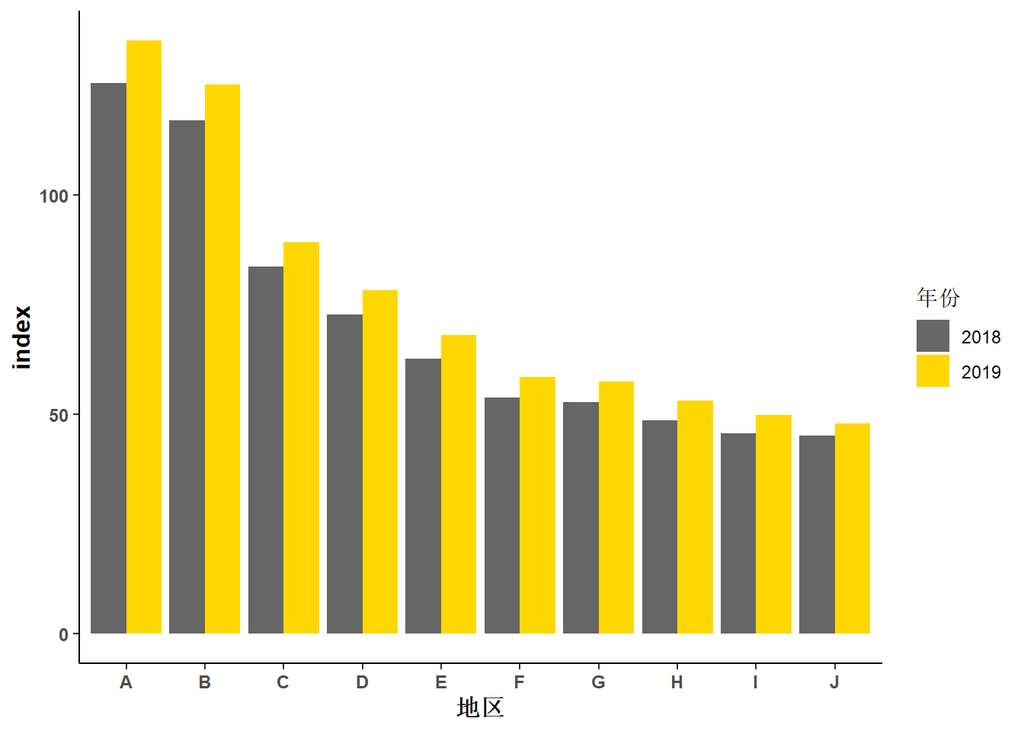

```r
#注意数据形式

df2 %>%
  ggplot() +
  geom_bar(aes(x = factor(reorder(area, -index)),      # 横轴为地区，按照index水平排列
               y = index, fill = factor(year)),        # 纵轴为index，按照年份分组
               stat="identity", position = "dodge") +
  labs(x = "地区", y = "index", fill = "年份") + # 添加坐标轴标签
  scale_fill_manual(breaks = c(2018, 2019),          #设置不同组的分组
                    values = c("gray40", "gold"),    #设置不同组的颜色
                    labels = c('2018','2019')) +     #设置不同组的图例标签
    theme(axis.text = element_text(face = "bold",size=9), #仍然是设置主题
          axis.title = element_text(face = "bold",size=12),
          panel.background = element_rect(fill = "transparent"),
          panel.border=element_rect(fill='transparent',
                                    color='transparent'),
          axis.line = element_line(color = "black"))
```

## 2.4 堆积组柱状图

- 堆积柱状图和双组柱状图非常相似仅有一个参数的变化：position。

```r
df2<-read.xlsx("mydata.xlsx",2)                          #导入index数据
df2[1:5,]                                             #数据展示
```

```
##   area     index year
## 1    A 135.23486 2019
## 2    B 125.13719 2019
## 3    C  89.26078 2019
## 4    D  78.31411 2019
## 5    E  68.14956 2019
```

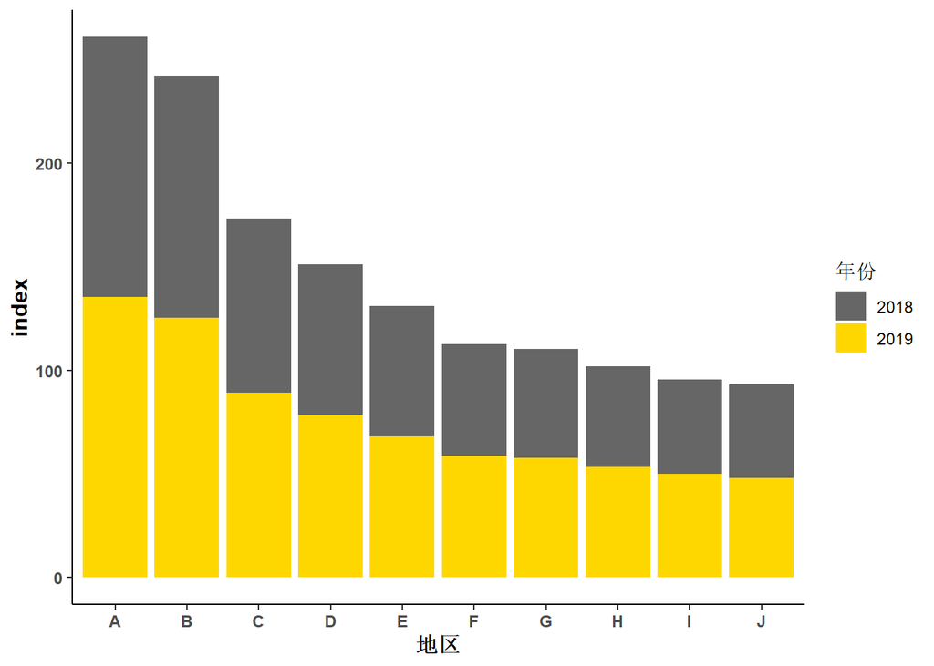

```r
df2 %>%
  ggplot() +
  geom_bar(aes(x = factor(reorder(area, -index)),      # 横轴为地区，按照index水平排列
               y = index, fill = factor(year)),        # 纵轴为index，按照年份分组
               stat="identity",position ='stack' ) +
  labs(x = "地区", y = "index", fill = "年份") + # 添加坐标轴标签
  scale_fill_manual(breaks = c(2018, 2019),          #设置不同组的分组
                    values = c("gray40", "gold"),    #设置不同组的颜色
                    labels = c('2018','2019')) +     #设置不同组的图例标签
    theme(axis.text = element_text(face = "bold",size=9), #仍然是设置主题
          axis.title = element_text(face = "bold",size=12),
          panel.background = element_rect(fill = "transparent"),
          panel.border=element_rect(fill='transparent',
                                    color='transparent'),
          axis.line = element_line(color = "black"))
```

# 3、折线图

## 3.1折线图参数解释

折线图作为反映数据变化趋势的重要图表也常常被用在数据分析中， 与python不同的地方是，python用一个函数plot可以把点和线都画了，这里需要分别绘制点图和线图，所以这一部分包含了两种geom函数，主要用到的函数为：

- ggplot()中加入group = 1语句说明数据均为一组，因为本数据集中年份按文本数据处理，所以需要这一参数才能绘制折线图。
- geom_line(…)表示绘制折线图，col为颜色设定，size为线条粗细。
- geom_point(…)表示绘制点，size为点的大小,shape为点的形状，col为颜色设定。

## 3.2单条折线图

- 这一部分尝试绘制2010-2019年十年间的index的折线图,首先导入数据并展示数据的前5行，然后绘制图像。

```r
df3<-read.xlsx("mydata.xlsx",3)    #导入index数据
df3[1:5,]
```

```
##   Time allindex
## 1 2010 41.21193
## 2 2011 48.79402
## 3 2012 53.85800
## 4 2013 59.29632
## 5 2014 64.35631
```

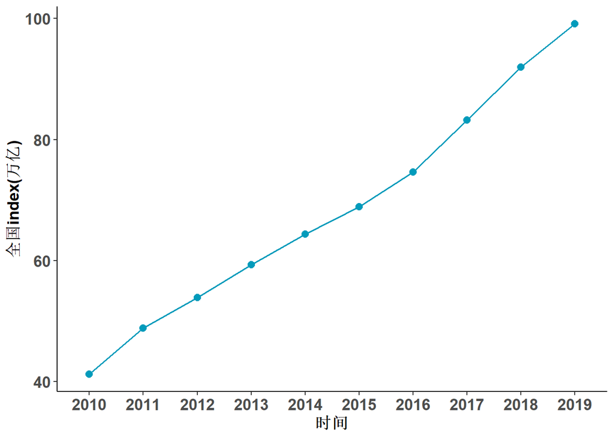

```r
df3 %>%
  ggplot(mapping = aes(x=Time, y=allindex,group=1))+
  geom_line(col = '#029bbb',size = 0.7)+
  geom_point(size=4, shape=20,col = '#029bbb')+
  labs(x = "时间", y = "全国index(万亿)") +
  theme(axis.text = element_text(face = "bold",size=13),
      axis.title = element_text(face = "bold",size=13),
      panel.background = element_rect(fill = "transparent"),
      panel.border=element_rect(fill='transparent', color='transparent'),
      axis.line = element_line(color = "black"))
```

对于多条折线图时，与柱状图一致，首先需要注意数据集的形式，然后会用的函数有：

- ggplot()中加入group语句确定分组。
- geom_line()和geom_point()语句中均加入aes(color=class)语句，设置不同颜色。

## 3.3多条折线图

如果我们想绘制有多条折线的折线图，则需要注意数据的格式，以及加入一些分类的语句帮助我们绘制多条折线图，这里我们采用北京和上海的2010-2019年十年间的index绘制折线图。

```r
df4<-read.xlsx("mydata.xlsx",4)    #导入index数据
df4[1:5,]
```

```
##   Time    index class
## 1 2010 14.11358     A
## 2 2011 16.25193     A
## 3 2012 17.87940     A
## 4 2013 19.80081     A
## 5 2014 21.33083     A
```

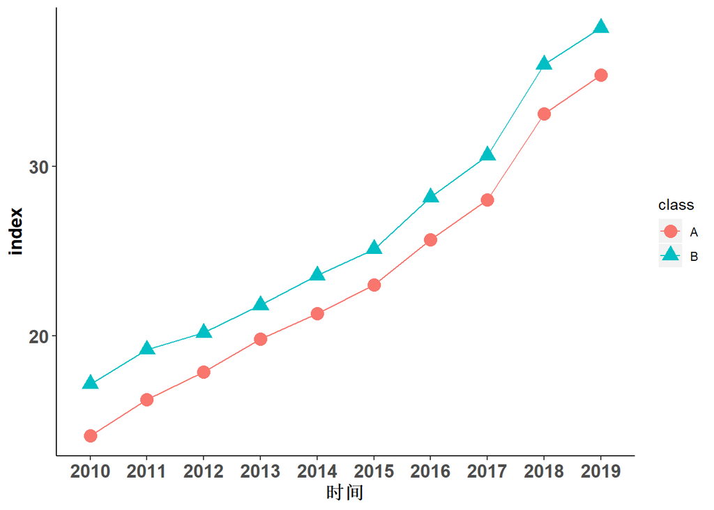

```r
df4 %>%
  ggplot(mapping = aes(x=Time,y=index,group=class,shape = class))+
  geom_line(aes(color=class))+
  geom_point(size=4,aes(color=class))+
  labs(x = "时间", y = "index") +
  theme(axis.text = element_text(face = "bold",size=13),
      axis.title = element_text(face = "bold",size=13),
      panel.background = element_rect(fill = "transparent"),
      panel.border=element_rect(fill='transparent', color='transparent'),
      axis.line = element_line(color = "black"))
```

# 4、箱线图

## 4.1箱线图参数解释

箱线图也是统计中比较重要的一类图形，是一种用作显示一组数据分散情况资料的统计图。这里用到的函数有：

- geom_boxplot()中aes()设置x,y轴数据，其中x是分类数据，然后fill参数表示按分类填涂颜色,一组时可以直接等于颜色，varwidth表示是否按数据量设定箱体宽度。
- scale_fill_manual()表示对箱体颜色的设定，首先breaks表示分组，valuess设定每一组的颜色，labels表示分组标签的设定

## 4.2单箱线图

- 这一部分尝试绘制2019年31个地区的index的箱线图,31个地区可以被分为4类，(A,B,C,D)。根据分组后，绘制四个区域的2019年index箱线图。

```r
df5 <- read.xlsx("mydata.xlsx",5)    #导入index数据
df5[1:5,]
```

```
##   area index2019 class
## 1   a1  44.42635     A
## 2   a2  17.71498     A
## 3   a3  44.09125     A
## 4   a4  47.92308     A
## 5   a5 125.13719     A
```

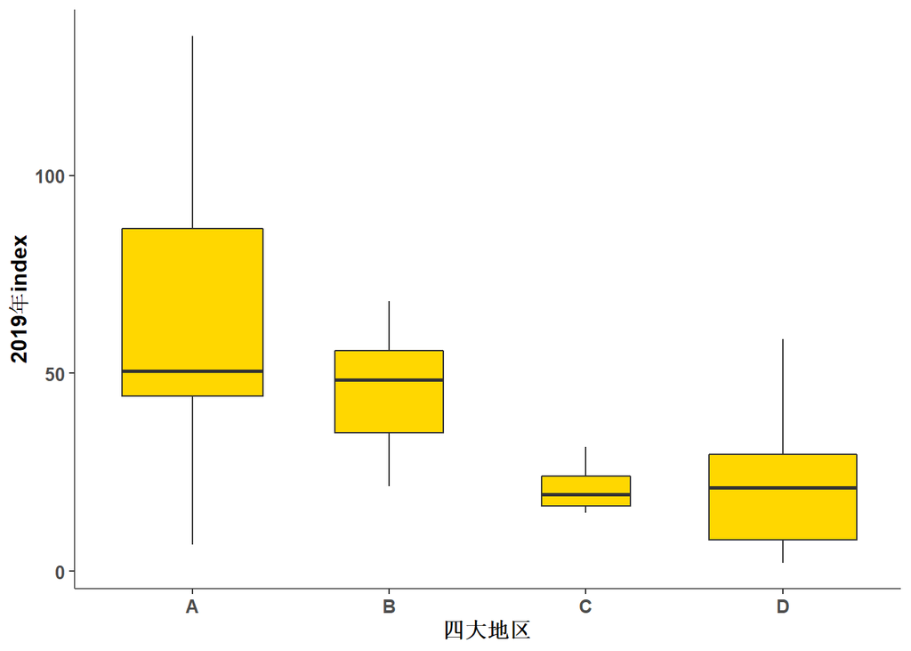

```r
#数据的形式仍然是面板数据的形式

df5 %>%
  # 画图
  ggplot() +
    # 横轴为地区
    # 纵轴为2019年index
    geom_boxplot(aes(x = factor(class, levels = c("A", "B", "C","D")),
                     y = index2019,fill = "gold"),varwidth = T) +#箱体宽度
    # 添加坐标轴标签
    labs(x = "四大地区", y = "2019年index") +
    # 设置箱子颜色
    scale_fill_manual(breaks = 1, values = "gold") +
    # 调整画板主题及字体大小
    theme(axis.text = element_text(face = "bold",size=10),
          axis.title = element_text(face = "bold",size=12),
          panel.background = element_rect(fill = "transparent"),
          panel.border=element_rect(fill='transparent', color='transparent'),
          axis.line = element_line(color = "gray40"))
```

对于多组箱线图时，与柱状图一致，首先需要注意数据集的形式，然后通过函数对不同分组进行设置。

## 4.3双箱线图

- 这一部分尝试绘制2018,2019年31个地区的index的箱线图,仍然采用4个分组，对比2018和2019两个年度的变化。

```r
df6 <- read.xlsx("mydata.xlsx",6)    #导入index数据
df6[1:5,]
```

```
##   class    index year
## 1     A 41.58114 2018
## 2     A 16.78383 2018
## 3     A 40.81322 2018
## 4     B 20.04341 2018
## 5     C 20.27310 2018
```

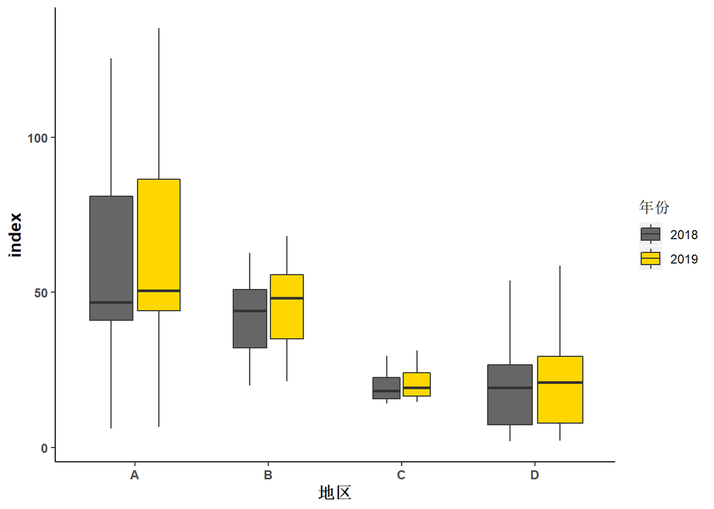

```r
df6 %>%
  # 画图
  ggplot() +
    # 横轴为地区
    # 纵轴为index
    geom_boxplot(aes(x = factor(class, levels = c("A", "B", "C","D")),
                     y = index, fill = factor(year)),varwidth = T) +
    # 添加坐标轴标签
    labs(x = "地区", y = "index", fill = '年份') +
    # 设置箱子颜色
    scale_fill_manual(breaks = c(2018, 2019),
                      values = c("gray40", "gold"),
                      labels = c('2018','2019')) +
    # 调整画板主题及字体大小
    theme(axis.text = element_text(face = "bold",size=9),
          axis.title = element_text(face = "bold",size=12),
          panel.background = element_rect(fill = "transparent"),
          panel.border=element_rect(fill='transparent', color='transparent'),
          axis.line = element_line(color = "black"))
```

# 总结

上文介绍了关于ggplot2包的一部分函数，适用于一般的绘图要求，关于更多的设定大家可以参考help文档，或者在CSDN的网站查询，这一网站上有很多用户的总结，非常实用。

以上是讲座的全部内容，因为我对于数据可视化的操作也未达到炉火纯青的水平，所以过程中可能会存在一些错误，如有错误欢迎大家指正！